# How your song becomes a hit

# The differences between countries

After presenting the output of our analysis with respect to the three countries individually, we thought it would be interesting to compare them to get a more comprehensive view. We decided to run this comparison analysis on two levels: firstly on the entire dataset, including all songs for the three countries under consideration, and secondly on a reduced dataset, which only includes the top 10 songs.

```
##                Df Sum Sq Mean Sq F value Pr(>F)
## region          2   1.74  0.8716   38.54 <2e-16 ***
## Residuals   12930 292.39  0.0226
## ---
## Signif. codes:  0 '***' 0.001 '**' 0.01 '*' 0.05 '.' 0.1 ' ' 1
```

```
##
##  Pairwise comparisons using t tests with pooled SD
##
## data:  chart_total$danceability and chart_total$region
##
##    au      it
## it 1       -
## us 1.8e-14 3.8e-12
##
## P value adjustment method: bonferroni
```

In order to perform two statistical tests simultaneously, we decided to execute the Bonferroni t-test, which allowed us to compare different t-test results. We wanted to understand how the three countries behave in relation to the three most intresting variables considered so far – danceability, loudness and energy.

The first test we run was to compare the role of danceability in Australia vs Italy vs US. The test resulted to be significant with p-value lower than 0.05, meaning that we can reject the null hypothesis. Indeed, by looking at the adjusted p-value for the mean difference in danceability scores, we can notice that there are two significant difference: the first one between Australia and US and the second one between Italy and the US.

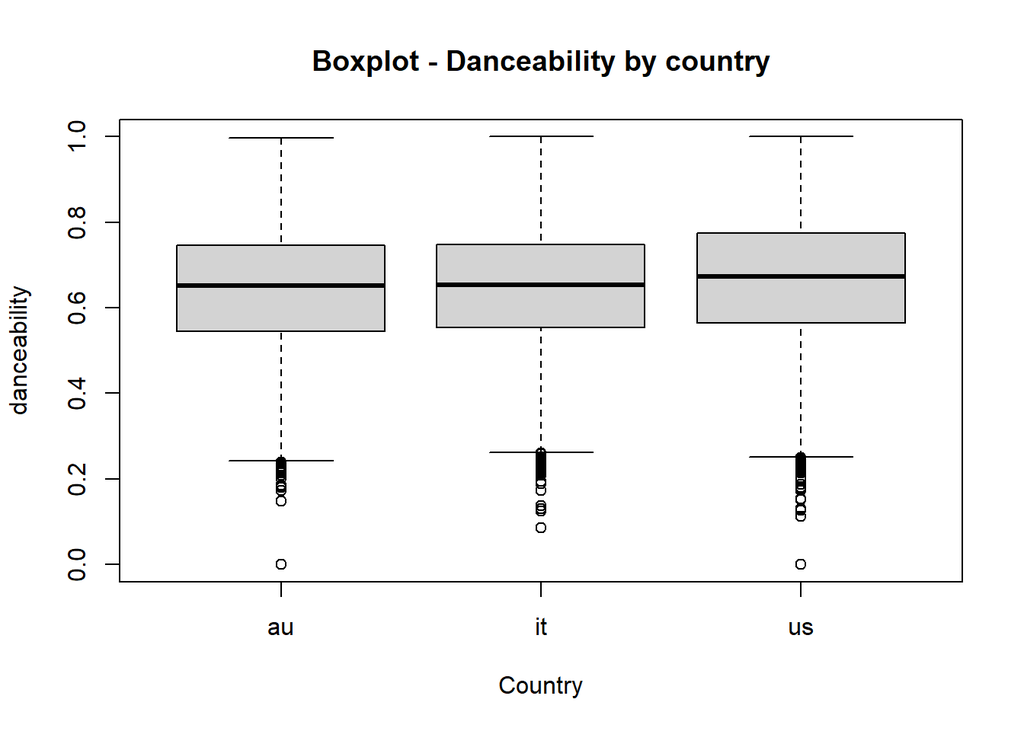

The same results of the Bonferroni t-test can be observed graphically in the following boxplots. Italy and Australia do not present significant differences, as their boxplots are almost identical. On the other hand, comparing US with Australia and Italy it is noticeable that there is a median difference. This result shows us how danceability has a slightly increased importance in the US than in the other two countries.

```
##                Df Sum Sq Mean Sq F value   Pr(>F)
## region          2   0.13 0.06724   18.31 1.15e-08 ***
## Residuals   12930  47.49 0.00367
## ---
## Signif. codes:  0 '***' 0.001 '**' 0.01 '*' 0.05 '.' 0.1 ' ' 1
```

```
##
##  Pairwise comparisons using t tests with pooled SD
##
## data:  chart_total$loudness and chart_total$region
##
##    au      it
## it 1.6e-05 -
## us 0.99    2.5e-08
##
## P value adjustment method: bonferroni
```

The following Bonferroni t-test aims at understanding the difference in the role of loudness in the three countries. The p-value is very low, meaning that we can reject the null hypothesis (according to which all means are equal). Looking at the comparisons, we can observe that there is a significant difference between Italy vs Australia and Italy vs the US.

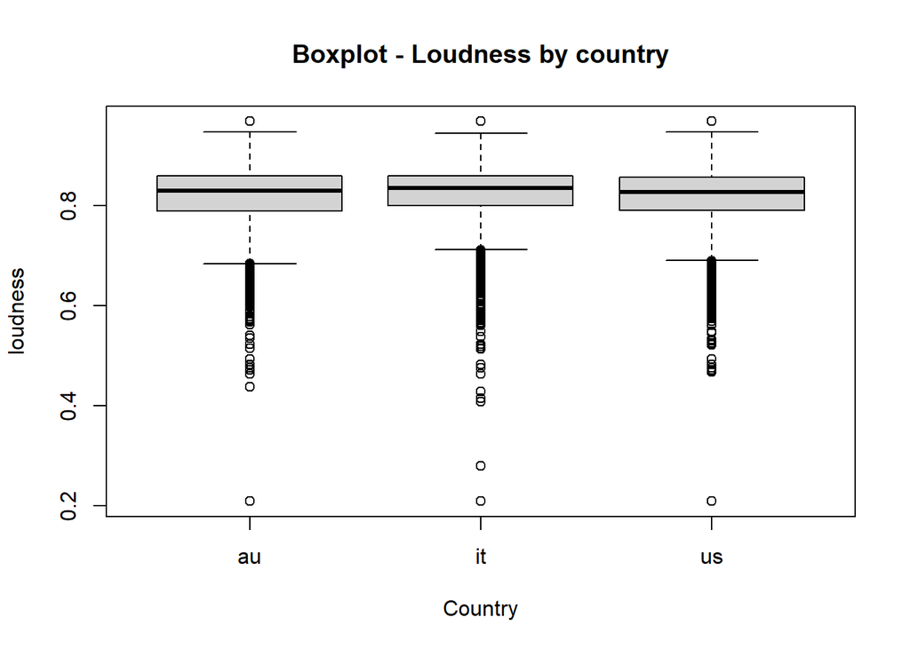

Following the results of the t-test, we can look at its graphical representation through the use of boxplots. Australia and US look almost identical as their adjusted p-value for the mean difference in loudness scores is equal to 0.99 (almost 1). Instead, Italy shows that loudness is more determinant in making the songs reach the top rankings.

```
##                Df Sum Sq Mean Sq F value Pr(>F)
## region          2    3.3  1.6746   51.58 <2e-16 ***
## Residuals   12930  419.8  0.0325
## ---
## Signif. codes:  0 '***' 0.001 '**' 0.01 '*' 0.05 '.' 0.1 ' ' 1
```

```
##
##  Pairwise comparisons using t tests with pooled SD
##
## data:  chart_total$energy and chart_total$region
##
##    au      it
## it 1.0e-05 -
## us 5.2e-07 < 2e-16
##
## P value adjustment method: bonferroni
```

Lastly, we performed the Bonferroni t-test to understand the difference in the role of energy in the three countries. The test is against significant, meaning that we accept the alternative hypothesis assuming that the means are different. By observing the adjusted p-values we can notice significant differences between all countries.

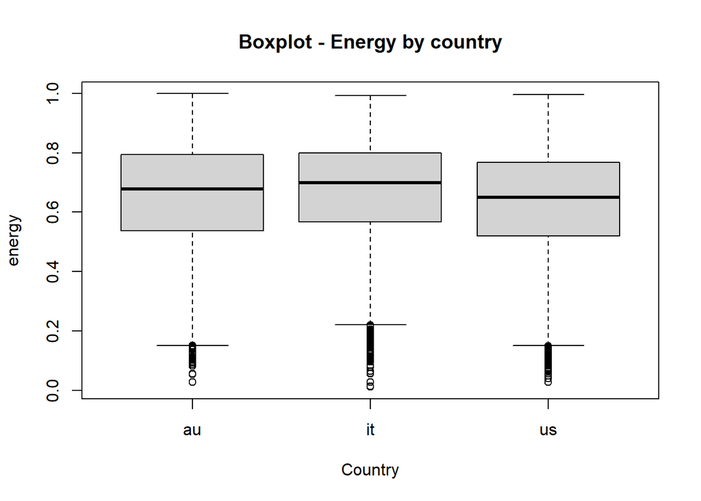

To get a more detailed understanding, we decided to graphically represent the results of the last t-test. We can see that energy is most valued in Italy, while it has the lowest median in US. We can therefore conclude that energy has different values in the three countries, but clearly it is most loved in Italy.

```
##             Df  Sum Sq  Mean Sq F value Pr(>F)
## region       2 0.01462 0.007312   0.634  0.538
## Residuals   27 0.31133 0.011531
```

```
##
##  Pairwise comparisons using t tests with pooled SD
##
## data:  chart_short_countries$danceability and chart_short_countries$region
##
##    au   it
## it 1.00 -
## us 1.00 0.88
##
## P value adjustment method: bonferroni
```

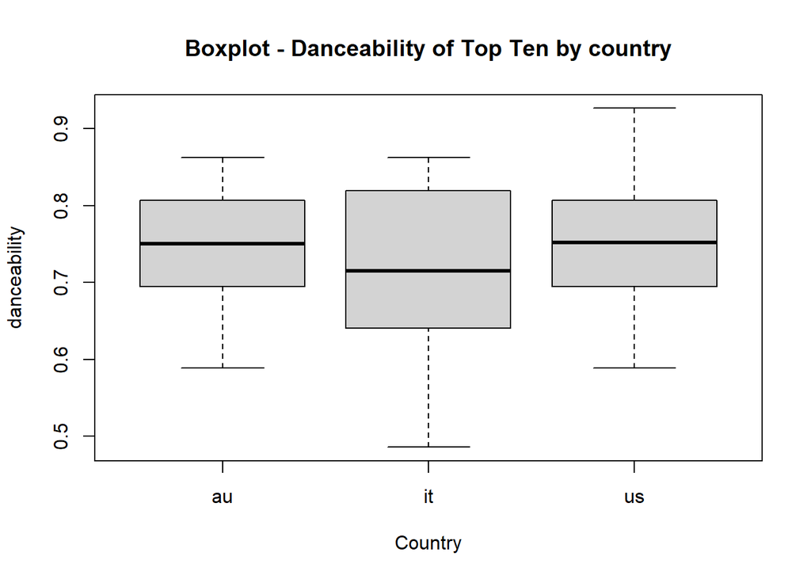

We now conduct the same tests but instead of looking at all the songs we focus on the Top 10. To compare the means and standard deviation of our three matched groups, namely Top 10 songs in Australia, Italy and the US we conduct a pairwise comparisons using t-tests with pooled SD. To evaluate if there is a statistically significant difference between the means of these three independent groups we look at the p-value of the ANOVA. Given the high p-value we accept the null hypothesis that the mean danceability score is the same for each country’s Top 10 list of songs.

```
##             Df  Sum Sq  Mean Sq F value Pr(>F)
## region       2 0.00218 0.001089   0.631   0.54
## Residuals   27 0.04657 0.001725
```

```
##
##  Pairwise comparisons using t tests with pooled SD
##
## data:  chart_short_countries$loudness and chart_short_countries$region
##
##    au   it
## it 0.81 -
## us 1.00 1.00
##
## P value adjustment method: bonferroni
```

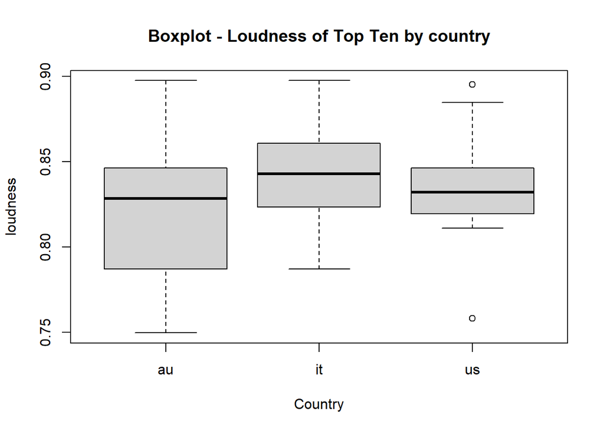

Again, to check whether there is a statistically significant difference between the means of loundness across our three groups, a one-way ANOVA is utilized. Also in this case the high p-value tells us that the mean loudness score is the same for each country.

```
##             Df Sum Sq Mean Sq F value Pr(>F)
## region       2 0.0487 0.02435   1.756  0.192
## Residuals   27 0.3744 0.01387
```

```
##
##  Pairwise comparisons using t tests with pooled SD
##
## data:  chart_short_countries$energy and chart_short_countries$region
##
##    au   it
## it 0.27 -
## us 1.00 0.48
##
## P value adjustment method: bonferroni
```

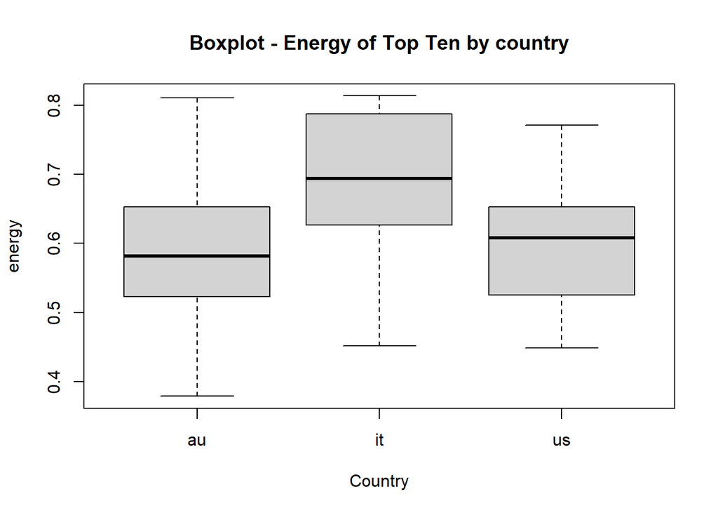

We conduct the same test also to check statistical difference in means of energy. Also in this case, the high p-value tells us that the mean energy score is the same for each country.

Hence, we can conclude that while these three factors were all significantly different in means when taking into consideration all the songs, they are not while taking into consideration only the Top 10 songs. Hence, all the hit songs are very similar across countries.

The final step in our work is a joint comparison of spider plots for all three countries in order to identify some common and individual patterns.

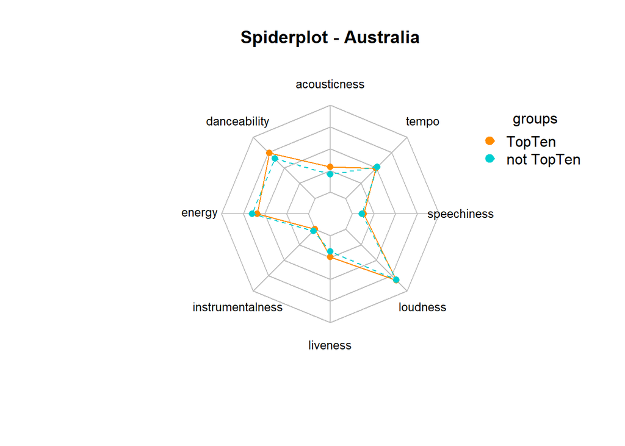

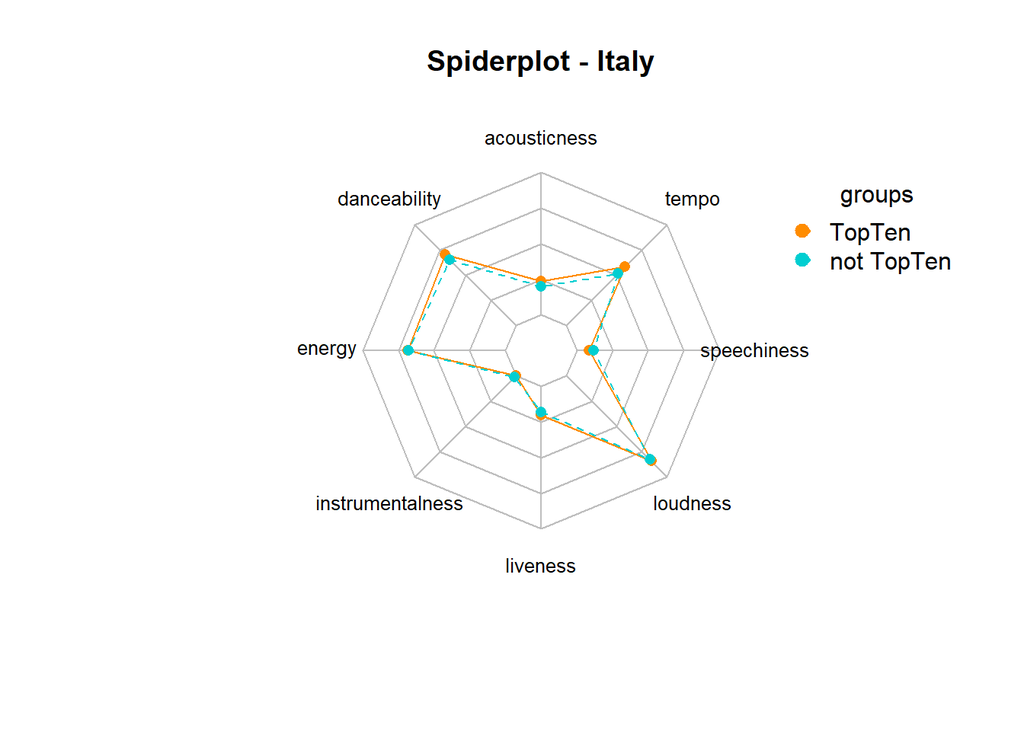

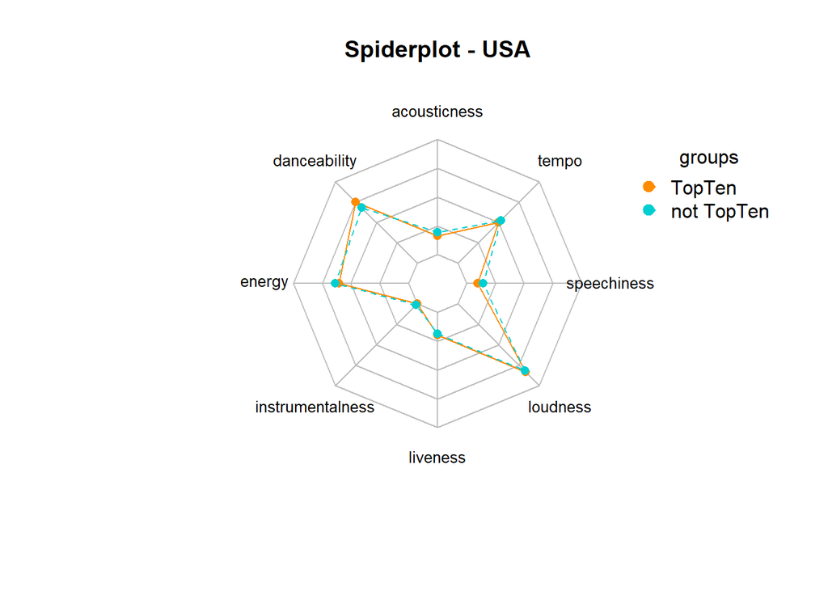

Common issues: First of all, we can identify three main, strongest features that are most important and strongly represented in the charts. These are danceability, energy and loudness. What is more, although energy has a strong position, it is more common for a not top 10 tracks. Secondly, there are some features which hold the weakest positions for all three countries and, therefore, are not common or characteristic for songs in the charts of those countries. These are instrumentalness, speechiness, liveness and acousticness.

Individual patterns: Among the strongest features there are some little individual differences that we would like to draw attention to. The level of danceability and loudness stay the same for all three countries, while the position of energy differs. It is more typical for Italian charts to have more energetic songs (at the same time, both for the top 10 and for non-top 10 tracks). Another thing is the appearance of a tempo feature, that is also more typical for an Italian top 10 chart. Among the weakest features there are also some individual differences. For example, liveness of a song is more inherent for top 10 tracks on the Australian market, while for others (especially for USA) there is not that big difference among top 10 and not top 10. Another interesting pattern occurs with acousticness. This feature is much more common for top 10 tracks in Australia and Italy, while for the USA this is more inherent for not top 10 songs.

## Conclusion

Coming to our conclusion, we should remember our main questions that were stated in this work. We tried to examine what is standing behind the real chart hits and whether there are differences among various countries: Australia, Italy and the USA.